# Introduction to Quantitative Variables

P. Lombardo

## Load packages and data sets

```r
library(tidyverse)
two_stores<-read.csv("data/two_stores.csv", header = T,
                     stringsAsFactors = T)
source('source_files/general.R')
```

# Quantitative Variables

## Quantitative Summaries

Measures of center: `mean()`, `median()`, and `mode()`.

Quick summaries

```r
#place code here
mean(two_stores$sales)
```

```
## [1] 51.3686
```

```r
two_stores %>%
    pull(sales) %>%
    mean()
```

```
## [1] 51.3686
```

Making Summary Tables with `summarize()`

```r
two_stores %>%
    summarize(
    # list our summaries here: mean, median, sample size
        sample_size = n(),
        avg_sales = mean(sales),
        median_sales = median(sales)
    )
```

```
##   sample_size avg_sales median_sales
## 1         200   51.3686        50.79
```

The summary table above combines both stores together into one large data set. What if we want the same summaries, but separately for each store location?

```r
two_stores %>%
    group_by(store) %>%
    summarize(
    # list our summaries here: mean, median, sample size
        sample_size = n(),
        avg_sales = mean(sales),
        median_sales = median(sales),
        min = min(sales),
        max = max(sales)
    )
```

```
## # A tibble: 2 × 6
##   store   sample_size avg_sales median_sales   min   max
##   <fct>         <int>     <dbl>        <dbl> <dbl> <dbl>
## 1 Beverly         100      50.8         50.9  43.0  60.4
## 2 Boston          100      52.0         50.4  30.6  80.9
```

**Exercise.** Look at the summary table above comparing the two stores. What can we say so far about the two stores? Do the sales in Beverly seem different than the sales in Boston?

*It seems like these stores sales are about the same, based on these summary statistics.*

*For those interested*: we can switch the rows and columns of these summary tables if we want, but it involves some trickery. I wrote a small `flip_tibble()` function to accomplish this and it was “sourced” in the first code chunk with the `general.R` file. Try it below!

```r
# copy and past the table, then add %>% flip_tibble() to the end
```

### Visualizing with Histograms

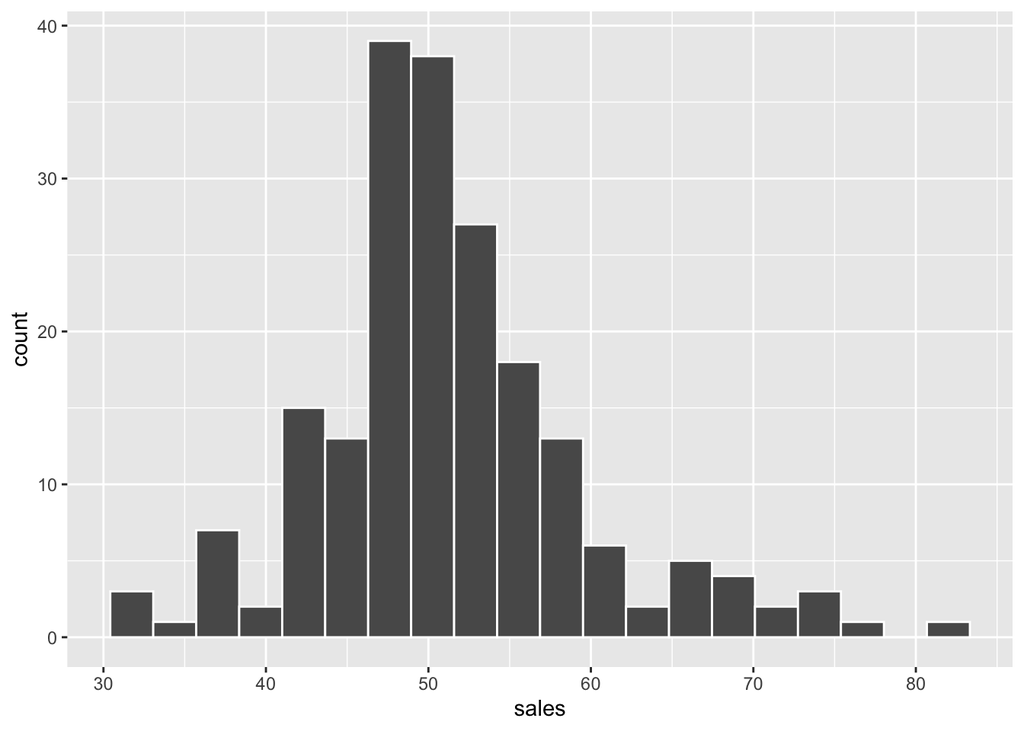

```r
#Place code here to explore a basic histogram
ggplot(data = two_stores,
       aes(x = sales))+
    geom_histogram(color="white",
                   bins = 20)
```

```r
# A little ugly at first, let's make some modifications...
    # bins = ... or
    # breaks = seq(start, stop, by = step)
    # color = "white"
```

### Measures or Variation

While *measures of center* try to summarize where the “center” of the data values falls, *measures of variation* attempt to describe the degree to which the data values are spread out. Let’s revisit our stores from the lens of *variation* in sales.

Here are the usual measures of variation:

- standard deviation `sd()` (and its counterpart variance `var()`)
- inter-quartile range `IQR()` (*We will talk about IQR in the future lesson.*), and
- range, defined as the maximum value minus the minimum.  
  There is no simple function for this, but also the least useful, in my opinion.

**Exercise.** Copy and paste the summary table from above, but this time let’s add in the range and std. deviation in our summary.

```r
# place the copy here and modify it.
two_stores %>%
    group_by(store) %>%
    summarize(
    # list our summaries here: mean, median, sample size
        sample_size = n(),
        avg_sales = mean(sales),
        median_sales = median(sales),
        std.dev = sd(sales),
        IQR = IQR(sales),
        range = max(sales) - min(sales)
    ) %>%
    flip_tibble()
```

```
## # A tibble: 6 × 3
##   name         Beverly Boston
##   <chr>          <dbl>  <dbl>
## 1 sample_size   100     100
## 2 avg_sales      50.8    52.0
## 3 median_sales   50.9    50.4
## 4 std.dev         3.78   10.9
## 5 IQR             4.46   14.3
## 6 range          17.3    50.3
```

So, *what differentiates these two data sets?*

In terms of measures of center, the boston and beverly stores are about the same. However, we see a big difference in the measures of variation! Specifically, the boston store seems to have more variation, as indicated by larger values for standard deviation, IQR, and range.

Let’s visualize this. Ideally, we want to compare histograms for each store (rather than all together like we did above). We can do this in ggplot using a `facet_wrap(vars(...), nrow = ...)` layer.

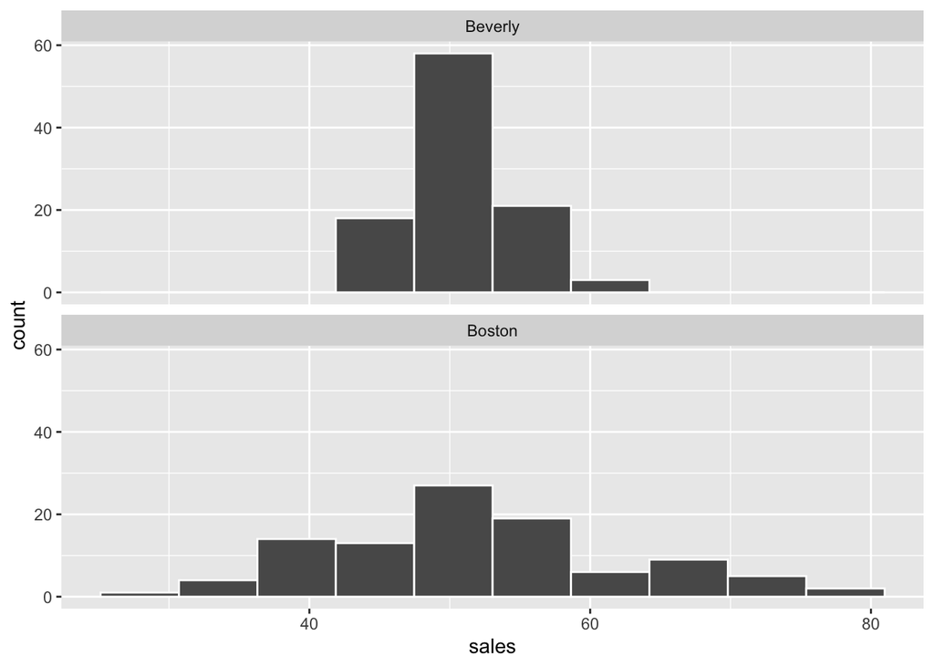

```r
ggplot(data = two_stores,
       aes(x = sales))+
    geom_histogram(bins = 10, color="white") +
    facet_wrap(vars(store),nrow = 2)
```

```r
    # add to the plot to separate the histograms

# adding facet_grid(store~.) will also work, we may explore this another time.
```

**Challenge:** Can you make each store’s histogram a different color? Here’s a hint… the fill of the histogram would depend on the data (specifically the `store` variable).

## The Empirical Rule

There is something very special about data that has a “normal shape.” This shape has the following characteristics:

- Most of the data tends to fall pretty close to the mean, with fewer measurements occurring in regions that are farther way from the mean.
- The data is symmetric about the mean; the shape to the left of the mean is a mirror image of the shape to the right of the mean. Moreover, the data falls with equal likelihood on either side of the mean.

Most importantly however, is that for normal shaped data the **Empirical Rule** applies!

> **Empirical Rule**: For a normal distribution, roughly 95% of the data falls within two standard deviations of the mean.
> - The interval of values that are two standard deviations from the mean will be referred to as the *empirical region*.
1. *What is the empirical region for Store 1?*

```r
# Place code here
two_stores %>%
    group_by(store) %>%
    summarize(
        avg_sales = mean(sales),
        std.dev = sd(sales),
        low_end = avg_sales - 2*std.dev,
        high_end = avg_sales + 2*std.dev,
    )
```

```
## # A tibble: 2 × 5
##   store   avg_sales std.dev low_end high_end
##   <fct>       <dbl>   <dbl>   <dbl>    <dbl>
## 1 Beverly      50.8    3.78    43.2     58.3
## 2 Boston       52.0   10.9     30.1     73.8
```

We can verify this

2. *What is the empirical region for Store 1?*

*Between 43.2 and 58.3, we expect 95% of the sales for the beverly store.*

How much of the data falls in the empirical region for each store? I made a little function that computes the percentage of data in the empirical region automatically (`empirical_pct()`); we use it below:

```r
two_stores %>%
    group_by(store) %>%
    summarize(empirical_percent = empirical_pct(sales))
```

```
## # A tibble: 2 × 2
##   store   empirical_percent
##   <fct>               <dbl>
## 1 Beverly              0.96
## 2 Boston               0.95
```

What if the shape is not normal? It depends, but the 95% estimate is no longer accurate or consistent. Here is a small [visualization.](https://stem.endicott.edu/pl-shiny/descriptive-stats/chebyshevs/)

**Note:** The Empirical Rule is *very important* for an application in inferential statistics, so please learn and understand it well. Here’s another way to think about it that will be particularly helpful in our future application:

> **Empirical Rule (Version 2):** Suppose a data set has a normal shape. Then if we select a single measurement from the data, there is a 95% chance that it will be less than two standard deviations from the mean.

This way of expressing the Empirical Rule starts to blend probability with proximity to the sample mean, and it is the foundation for the confidence interval technique!